# Commentary on Replication 2: Extension

Keeley MacAfee

2/25/2019

# Abstract

In this commentary, I aim to expand upon Ryan Enos’ article “Causal effect of intergroup contact on exclusionary attitudes.” Using the data he collected, I examine the magnitude of the change in response to the three survey questions Enos asked regarding opinions on immigration. In this case, I chose to use the magnitude of change to eliminate the inconsistency in measuring the change in response on the 1-5 strongly agree to strongly disagree scale, as the meaning of positive or negative change in response varies between questions. Thus, by examining age, education, and income, I determine which of these factors, if any, affect respondents’ malleability in either direction.

# All Respondents Regressions

In these three regressions, I use age, education, and income separately to determine if they had an impact on the magnitude of change in attitude among all of the respondents (control group and treated group).

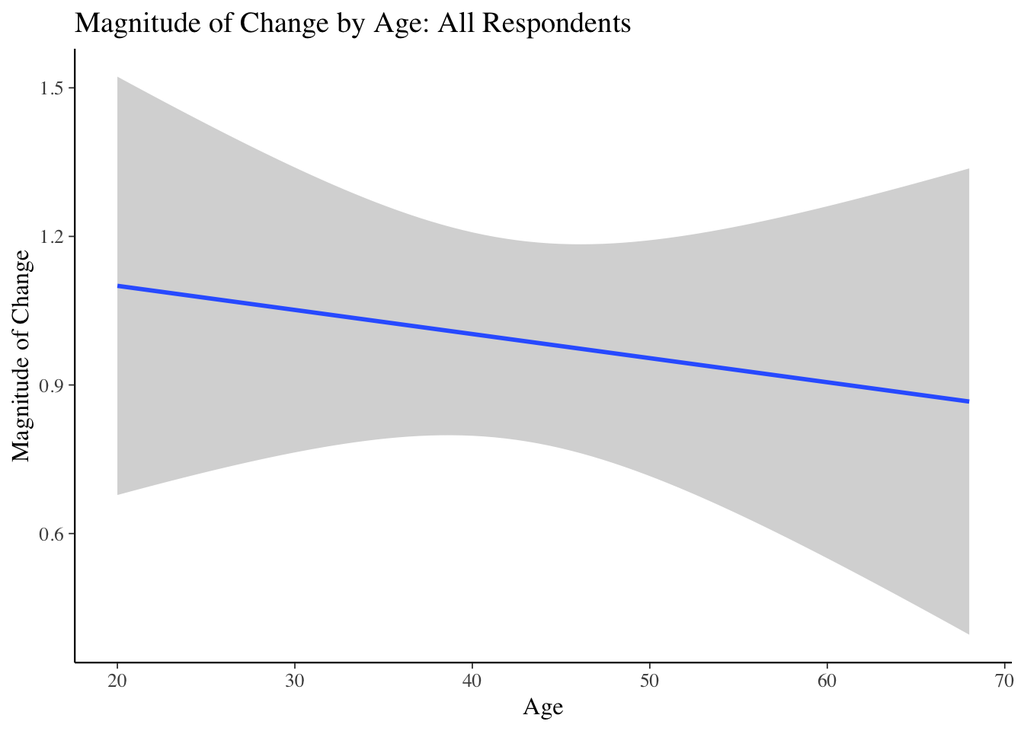

In this case, age is insignificant (p = 0.56).

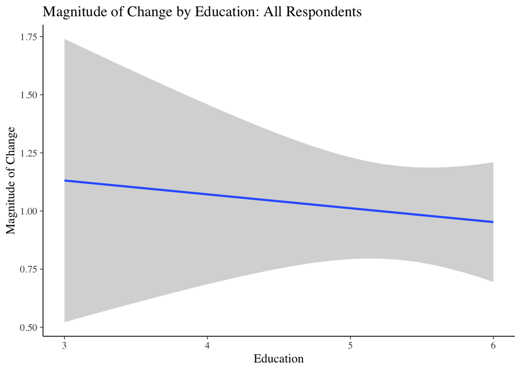

In this case, education is insignificant (p = 0.63).

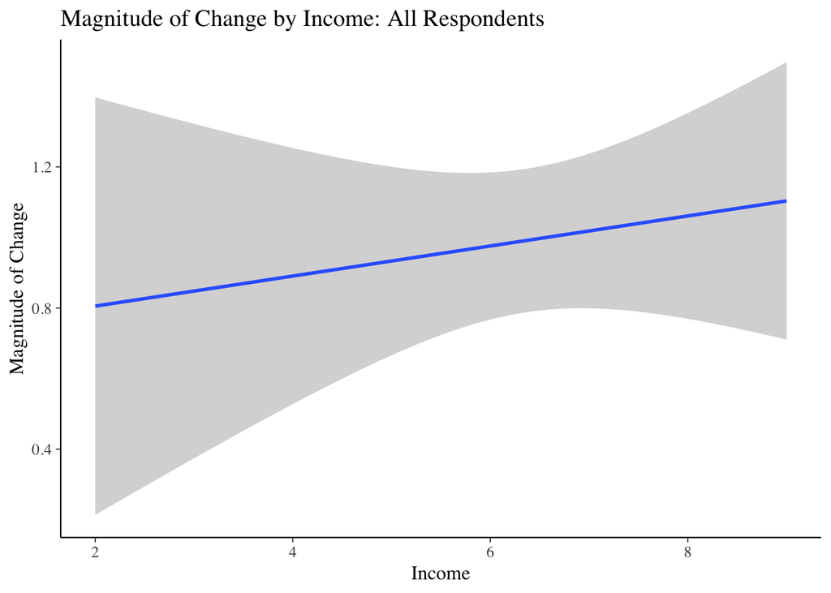

In this case, income is insignificant (p = 0.51).

# Control Group Regressions

In these three regressions, I use age, education, and income separately to determine if they had an impact on the magnitude of change in attitude among the control group.

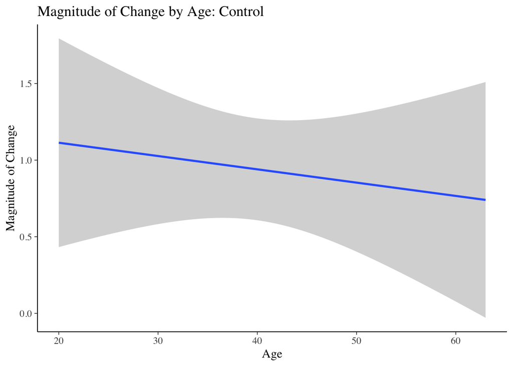

In this case, age is insignificant (p = 0.70).

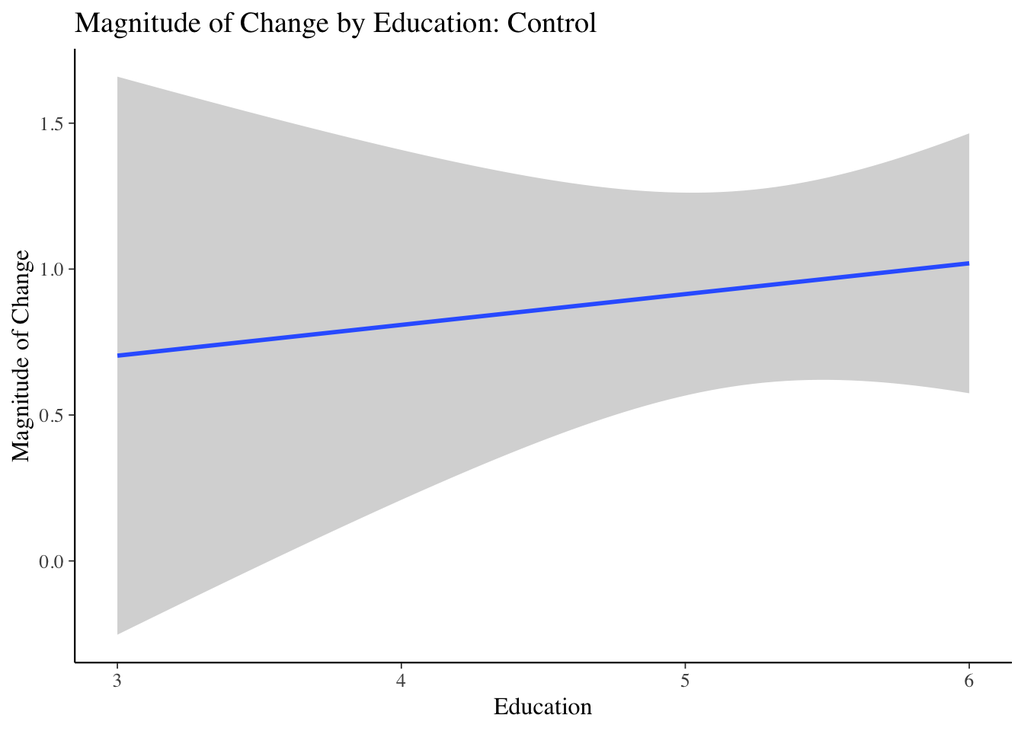

In this case, education is insignificant (p = 0.18).

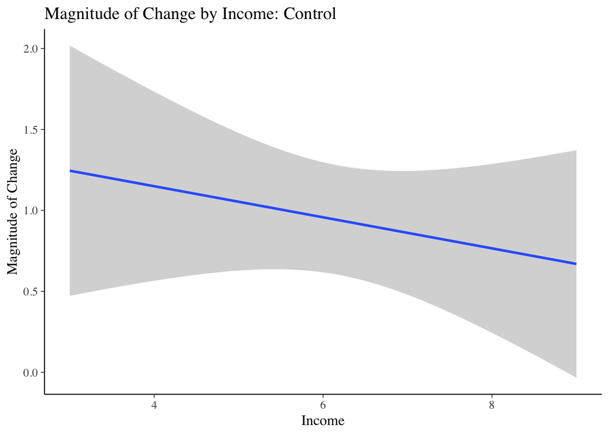

In this case, income is insignificant (p = 0.08).

# Treated Group Regressions

In these three regressions, I use age, education, and income separately to determine if they had an impact on the magnitude of change in attitude among the treated group.

[figure not shown]

In this case, age is insignificant (p = 0.56).

[figure not shown]

In this case, education is insignificant (p = 0.60).

[figure not shown]

In this case, income is insignificant (p = 0.38).

# Bonus Regression

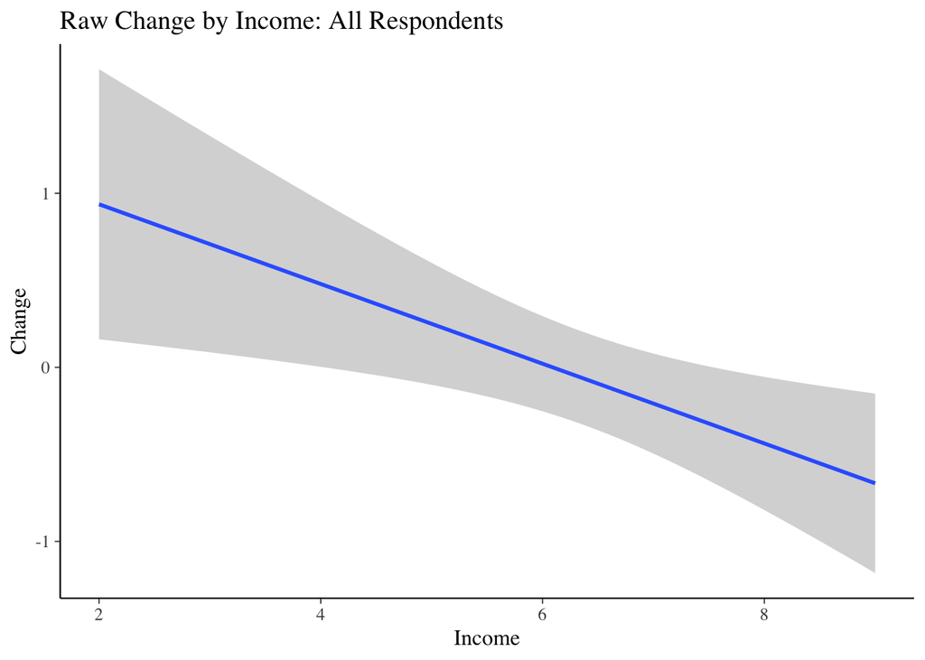

In this case, the intercept has a significant p value (0.01), and income is also significant (p =0.008). This regression shows that changes in income are related to changes in the direction, but not necessarily to the magnitude, of attitude shifts among respondents.

# Conclusion

My hypothesis that age, education, and income would impact the magnitude of respondents’ change in attitude proved to have no statistical support. I originally believed that these factors, age especially, would affect respondents’ responses to the treatment, with younger people being more impressionable in either direction. While age and magnitude have a slight negative correlation in all respondents, the control group, and the treatment group, there is still high variance in each case.